# 09 - Municipal Tablas

## Zarate

### Informe: Cifras electorales del Municipio de Zarate

Este documento integra cifras de cantidades de votos que obtuvieron las fuerzas en PASO de 2013, 15, 17, 19, 21.

Todos los numeros que se muestran son para el Partido de Zarate unicamente.

#### 1. Votos Positivos vs Blancos y Nulos

El nivel de participacion tipicamente es de casi 66000 votos positivos, unos casi 6000 blancos y cerca de 400 nulos.

En la tabla que sigue estan estos niveles medios, ademas de valores bajos o altos que sirven para tener un parametro de lo esperable.

|  | POSITIVO | BLANCO | NULO |
| --- | --- | --- | --- |
| nivel bajo | 58970 | 3480 | 380 |
| nivel medio | 65810 | 5780 | 420 |
| nivel alto | 68640 | 7200 | 600 |

A continuacion una tabla con la cantidad de votos positivos (cargo Dip. Nac.) en PASO y generales.

En 2013 y 2015, votaron cerca de 7000 personas mas en las generales que en las PASO.

En 2017 y 2019, esa brecha se acorto a menos de 3000.

|  | año | eleccion_tag | cargo_nombre | POSITIVO | BLANCO | NULO |
| --- | --- | --- | --- | --- | --- | --- |
| 0 | 2015 | PASO15n | Diputado Nacional | 57420 | 8130 | 390 |
| 1 | 2013 | PASO13n | Diputado Nacional | 60880 | 2260 | 1020 |
| 2 | 2021 | PASO21n | Diputado Nacional | 61060 | 3480 | 920 |
| 3 | 2011 | GRAL11n | Diputado Nacional | 61130 | 5780 | 340 |
| 4 | 2015 | GRAL15n | Diputado Nacional | 65060 | 7560 | 340 |
| 5 | 2019 | PASO19n | Diputado Nacional | 65810 | 7150 | 430 |
| 6 | 2013 | GRAL13n | Diputado Nacional | 67780 | 4360 | 760 |
| 7 | 2017 | PASO17n | Diputado Nacional | 68640 | 4490 | 500 |
| 8 | 2019 | GRAL19n | Diputado Nacional | 68760 | 4490 | 410 |
| 9 | 2017 | GRAL17n | Diputado Nacional | 71010 | 3460 | 650 |

#### 2. Votos por agrupacion - lista

Las listas que han sacado un caudal significativo (en los tramos nacional/provincial) son el kirchnerismo, el PRO, y el Massismo en 2013, 15 y 17.

En el tramo municipal el partido de Caffaro, Nuevo Zarate gano con 26500 votos en 2015 yendo solo. Pero en las paso del 19 yendo con el FdT, obtuvo 34900 votos, lo caul fue 1800 menos que el tramo de diputados y 3800 menos que el tramo de presidente. Es decir que al menos 10% de los que votaron a Alberto F. cortaron el tramo de Caffaro.

En las ultimas PASO de 2021 obtuvimos 19000 votos, contra unos 9000 y 16000 (total 25000) que sacaron las listas internas del PRO. Fue la primera eleccion que perdio nuestro sector en Zarate.

|  | año | eleccion_tag | cargo_nombre | agrupacion_nombre | lista_nombre | POSITIVO |
| --- | --- | --- | --- | --- | --- | --- |
| 0 | 2013 | PASO13n | Concejal | FRENTE RENOVADOR | CORRIENTE RENOVADORA ... | 17300 |
| 1 | 2013 | PASO13n | Concejal | FRENTE SOCIAL DE LA P... | LINEA BLANCA Y CELEST... | 8800 |
| 2 | 2013 | PASO13n | Diputado Nacional | FRENTE PARA LA VICTORIA | LISTA 2 - CELESTE Y B... | 19900 |
| 3 | 2013 | PASO13n | Diputado Nacional | FRENTE PROGRESISTA CI... | UNIDAD PROGRESISTA - A | 8400 |
| 4 | 2013 | PASO13n | Diputado Nacional | FRENTE RENOVADOR | CORRIENTE RENOVADORA ... | 22000 |
| 5 | 2015 | GRAL15n | Concejales | ALIANZA FRENTE PARA L... | ALIANZA FRENTE PARA L... | 13700 |
| 6 | 2015 | GRAL15n | Concejales | ALIANZA UNIDOS POR UN... | ALIANZA UNIDOS POR UN... | 9800 |
| 7 | 2015 | GRAL15n | Concejales | CAMBIEMOS BUENOS AIRES | CAMBIEMOS BUENOS AIRES | 13700 |
| 8 | 2015 | GRAL15n | Concejales | NUEVO ZARATE | NUEVO ZARATE | 26500 |
| 9 | 2015 | PASO15n | Diputado Nacional | ALIANZA CAMBIEMOS | LISTA G EL CAMINO DEL... | 13500 |
| 10 | 2015 | PASO15n | Diputado Nacional | ALIANZA FRENTE PARA L... | A LISTA CELESTE Y BLA... | 23900 |
| 11 | 2015 | PASO15n | Diputado Nacional | ALIANZA UNIDOS POR UN... | A FRENTE RENOVADOR +A15 | 12700 |
| 12 | 2015 | PASO15n | Presidente | ALIANZA CAMBIEMOS | LISTA G EL CAMINO DEL... | 13600 |
| 13 | 2015 | PASO15n | Presidente | ALIANZA FRENTE PARA L... | A LISTA CELESTE Y BLA... | 26300 |
| 14 | 2015 | PASO15n | Presidente | ALIANZA UNIDOS POR UN... | A FRENTE RENOVADOR +A15 | 13200 |
| 15 | 2017 | PASO17n | Diputado Nacional | 1PAIS | UN PAIS UNIDO HOY Y S... | 11100 |
| 16 | 2017 | PASO17n | Diputado Nacional | CAMBIEMOS BUENOS AIRES | CAMBIANDO JUNTOS | 22900 |
| 17 | 2017 | PASO17n | Diputado Nacional | UNIDAD CIUDADANA | CELESTE Y BLANCA U | 27100 |
| 18 | 2019 | PASO19n | Concejal | FRENTE DE TODOS | CELESTE Y BLANCA - 2 | 34900 |
| 19 | 2019 | PASO19n | Concejal | JUNTOS POR EL CAMBIO | 1A - AMARILLO | 11500 |
| 20 | 2019 | PASO19n | Concejal | JUNTOS POR EL CAMBIO | 3A - ROJO | 9400 |
| 21 | 2019 | PASO19n | Diputado Nacional | FRENTE DE TODOS | CELESTE Y BLANCA | 36700 |
| 22 | 2019 | PASO19n | Diputado Nacional | JUNTOS POR EL CAMBIO | JUNTOS SOMOS EL CAMBIO | 20800 |
| 23 | 2019 | PASO19n | Presidente | FRENTE DE TODOS | CELESTE Y BLANCA - Al... | 38700 |
| 24 | 2019 | PASO19n | Presidente | JUNTOS POR EL CAMBIO | JUNTOS SOMOS EL CAMBI... | 20600 |
| 25 | 2021 | PASO21n | Concejales | FRENTE DE TODOS | CELESTE Y BLANCA 2 | 18300 |
| 26 | 2021 | PASO21n | Concejales | JUNTOS | B | 11300 |
| 27 | 2021 | PASO21n | Diputado Nacional | FRENTE DE TODOS | CELESTE Y BLANCA | 19000 |
| 28 | 2021 | PASO21n | Diputado Nacional | JUNTOS | DAR EL PASO | 8900 |
| 29 | 2021 | PASO21n | Diputado Nacional | JUNTOS | ES JUNTOS | 15900 |

#### Votos por sector politico

A continuacion tres tablas muestran la cantidad de votos que obtuvo cada sector a lo largo del tiempo.

Con el Frente de Todos de 2019, los votos de nuestro sector se sumaron con los del Massismo casi aritmeticamente. En el partido de Zarate Ademas influyo la situacion de avalancha de votos que tuvo el FdT en todo el pais.

Mas precisamente

- en 2013, obtuvimos 20000 votos y el massismo 22000 (42000)
- en 2015, obtuvimos 24000 votos y el massismo 13000 (37000)
- en 2017, obtuvimos 27000 votos y el massismo 11000 (38000)
- El frente de todos obtuvo 36700 votos en 2019.

En 2021 bajamos a 19000. Ademas del contexto nacional adverso, parece que se hubiera perdido el aporte diferencial de los votos massistas. O bien Massa se diluyo en el kirchnerismo y perdio su identidad diferenciada, o bien la candidatura de Tolosa Paz no interpelo a los votos massistas. Los votos de Tolosa PAz fueron aproximadamente la misma cantoidad que los de Insaurralde en 2013.

En esta eleccion, puede que esta situacion no se repita de la misma forma ya que el candidato es Massa y se supone que el nucleo duro kirchnerista va por lo menos a aportar el piso de los 20000 votos.

En cuanto al macrismo, tuvo un crecimiento fuerte que es un poco preocupante. Paso de 13500 votos en las PASO de 2015, llego a 23000 en la eleccion de E. Bullrich, 2017, y logro contener casi 21000 en la eleccion que Macri perdio fuertemente en 2019 y sumaron 25000 entre dos listas internas en 2021.

Sector FpV

|  | año | eleccion_tag | cargo_nombre | agrupacion_nombre | lista_nombre | lista_votos |
| --- | --- | --- | --- | --- | --- | --- |
| 0 | 2013 | PASO13n | Diputado Nacional | FRENTE PARA LA VICTORIA | LISTA 2 - CELESTE Y B... | 19900 |
| 1 | 2015 | PASO15n | Diputado Nacional | ALIANZA FRENTE PARA L... | A LISTA CELESTE Y BLA... | 23900 |
| 2 | 2015 | PASO15n | Presidente | ALIANZA FRENTE PARA L... | A LISTA CELESTE Y BLA... | 26300 |
| 3 | 2017 | PASO17n | Diputado Nacional | UNIDAD CIUDADANA | CELESTE Y BLANCA U | 27100 |
| 4 | 2019 | PASO19n | Diputado Nacional | FRENTE DE TODOS | CELESTE Y BLANCA | 36700 |
| 5 | 2019 | PASO19n | Presidente | FRENTE DE TODOS | CELESTE Y BLANCA - Al... | 38700 |
| 6 | 2021 | PASO21n | Diputado Nacional | FRENTE DE TODOS | CELESTE Y BLANCA | 19000 |

Sector Cambiemos

|  | año | eleccion_tag | cargo_nombre | agrupacion_nombre | lista_nombre | lista_votos |
| --- | --- | --- | --- | --- | --- | --- |
| 0 | 2015 | PASO15n | Diputado Nacional | ALIANZA CAMBIEMOS | LISTA G EL CAMINO DEL... | 13500 |
| 1 | 2015 | PASO15n | Presidente | ALIANZA CAMBIEMOS | LISTA G EL CAMINO DEL... | 13600 |
| 2 | 2017 | PASO17n | Diputado Nacional | CAMBIEMOS BUENOS AIRES | CAMBIANDO JUNTOS | 22900 |
| 3 | 2019 | PASO19n | Diputado Nacional | JUNTOS POR EL CAMBIO | JUNTOS SOMOS EL CAMBIO | 20800 |
| 4 | 2019 | PASO19n | Presidente | JUNTOS POR EL CAMBIO | JUNTOS SOMOS EL CAMBI... | 20600 |
| 5 | 2021 | PASO21n | Diputado Nacional | JUNTOS | DAR EL PASO | 8900 |
| 6 | 2021 | PASO21n | Diputado Nacional | JUNTOS | ES JUNTOS | 15900 |

Sector Massa

|  | año | eleccion_tag | cargo_nombre | agrupacion_nombre | lista_nombre | lista_votos |
| --- | --- | --- | --- | --- | --- | --- |
| 0 | 2013 | PASO13n | Diputado Nacional | FRENTE RENOVADOR | CORRIENTE RENOVADORA ... | 22000 |
| 1 | 2015 | PASO15n | Diputado Nacional | ALIANZA UNIDOS POR UN... | A FRENTE RENOVADOR +A15 | 12700 |
| 2 | 2015 | PASO15n | Presidente | ALIANZA UNIDOS POR UN... | A FRENTE RENOVADOR +A15 | 13200 |
| 3 | 2017 | PASO17n | Diputado Nacional | 1PAIS | UN PAIS UNIDO HOY Y S... | 11100 |

#### Circuitos Electorales Zarate

**Mapa de los circuitos electorales y cuanto pesan dentro del partido**

Lima tiene solo un 9% de los votantes, Zarate el 90%, las zonas rurales no influyen en el resultado

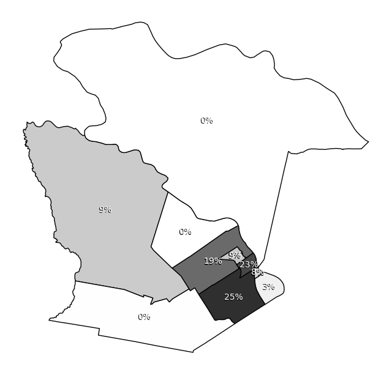

**Debajo los pesos relativos de cada uno de los circuitos**

|  | circuito_id | Porcentaje |
| --- | --- | --- |
| 0 | 001013 | 23.4 |
| 1 | 001014 | 25.3 |
| 2 | 001015 | 8.0 |
| 3 | 001016 | 3.7 |
| 4 | 001017 | 19.8 |
| 5 | 001018 | 9.8 |
| 6 | 001019 | 0.4 |
| 7 | 001020 | 0.1 |
| 8 | 001021 | 9.5 |
| 9 | 01013A | 0.2 |

#### Votos al PRO, por circuito.

Su zona de mayor fuerza es en el centro de Zarate, como suele suceder los centros de las ciudades tienen una poblacion que da con el perfil del votante PRO.

[figure not shown]

#### Votos al FdT, por circuito.

La zona de mayor fuerza es en la periferia de Zarate y en Lima. Esto se explica por el perfil socioeconomico de los alrededores de la ciudades.

[figure not shown]